# ESM 204 HW 4

Alessandra Puig-Santana and Shayan Kaveh

5/23/2022

```r
knitr::opts_chunk$set(echo = TRUE, message = F, warning = F)

# Attach packages

library(tidyverse)
library(here)
library(janitor)
library(broom)
library(equatiomatic)
library(patchwork)
```

### 1. Quadratic model of damages

```r
# Read in data
damages <- read_csv(here("damages.csv"))
warming <- read_csv(here("warming.csv")) %>%
  select(year:warming_pulse)
```

Using damages.csv, estimate a quadratic damage function relating the dollar value of damages to the change in global mean temperature. Estimate a model with a zero intercept because damages by construction must equal zero when there is no climate change. Plot your estimated damage function, overlaid with a scatterplot of the underlying data.

```r
# Need warming^2 to derive a quadratic model

damages$warming2 <- damages$warming^2

#run a quadratic regression for the damages
damages_quadratic <- lm(damages ~ 0 + warming + warming2, data = damages)

#output the model results
# summary(damages_quadratic)

# extract equation
# extract_eq(model = damages_quadratic, use_coefs = TRUE, coef_digits = 7)

# augment results
damages_predict <- augment(damages_quadratic)
```

$Damages = (1.94e13*warming^2) - (1.06e12*warming)$

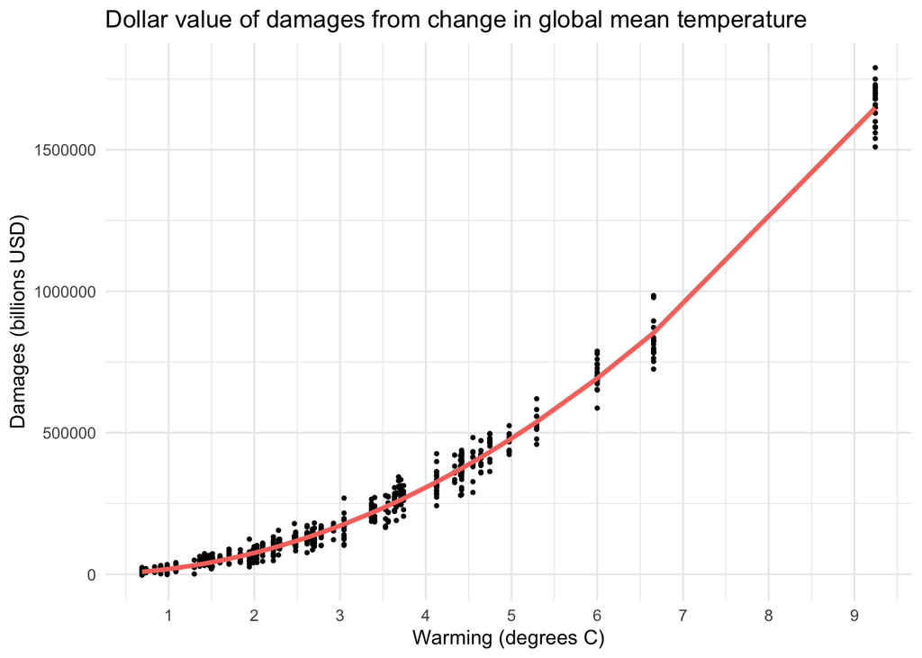

```r
# graph the quadratic damage function
ggplot(data = damages, aes(x = warming, y = damages/1e+9)) +
  geom_point(color = "black", size = 0.7) +
  geom_line(data = damages_quadratic, aes(x = warming, y = .fitted/1e+9, color = "darkseagreen"), size = 1.2) +
  theme_minimal() +
  labs(x = "Warming (degrees C)", y = "Damages (billions USD)", title = "Dollar value of damages from change in global mean temperature") +
  scale_x_continuous(n.breaks = 10) +
  theme(legend.position = "none")
```

### 2. Damage with a Carbon Pulse

Use warming.csv and your estimated damage function to predict damages in each year under the baseline climate and the pulse scenario. Make four plots: (1) damages over time without the pulse, (2) damages over time with the pulse, (3) the difference in damages over time that arises from the pulse, and (4) the difference in damages over time from the pulse per ton of CO2 (you can assume that each ton of the pulse causes the same amount of damage).

```r
damages <- function(warming) {
  damages <- damages_quadratic$coefficients[1]*warming + damages_quadratic$coefficients[2]*(warming^2)
  return(damages)
}
```

```r
# creating a new dataframe with differences and damages per ton based on degrees of warming
pulse <- warming %>%
  mutate(damages_baseline = damages(warming_baseline)) %>%
  mutate(damages_pulse = damages(warming_pulse)) %>%
  mutate(difference = damages_pulse - damages_baseline) %>%
  mutate(damage_per_ton = difference/35e+9)
```

```r
p1 <- ggplot(data = pulse, aes(x = year, y = damages_baseline/1e+9)) +
  geom_line(size = 1.2, color = "coral3") +
  labs(x = "Year", y = "Damages (billion USD)", title = "Damages from baseline warming") +
  theme_minimal()

p2 <- ggplot(data = pulse, aes(x = year, y = damages_pulse/1e+9)) +
  geom_line(size = 1.2, color = "coral3") +
  labs(x = "Year", y = "Damages (billion USD)", title = "Damages with carbon pulse") +
  theme_minimal()

p3 <- ggplot(data = pulse, aes(x = year, y = difference/1e+9)) +
  geom_line(size = 1.2, color = "coral3") +
  labs(x = "Year", y = "Difference in damages (billion USD)", title = "Difference in damages from \n baseline and carbon pulse") +
  theme_minimal()

p4 <- ggplot(data = pulse, aes(x = year, y = damage_per_ton)) +
  geom_line(size = 1.2, color = "coral3") +
  labs(x = "Year", y = "Difference in damages per ton CO2 (USD)", title = "Difference in damages from \n baseline and carbon pulse") +
  theme_minimal()
```

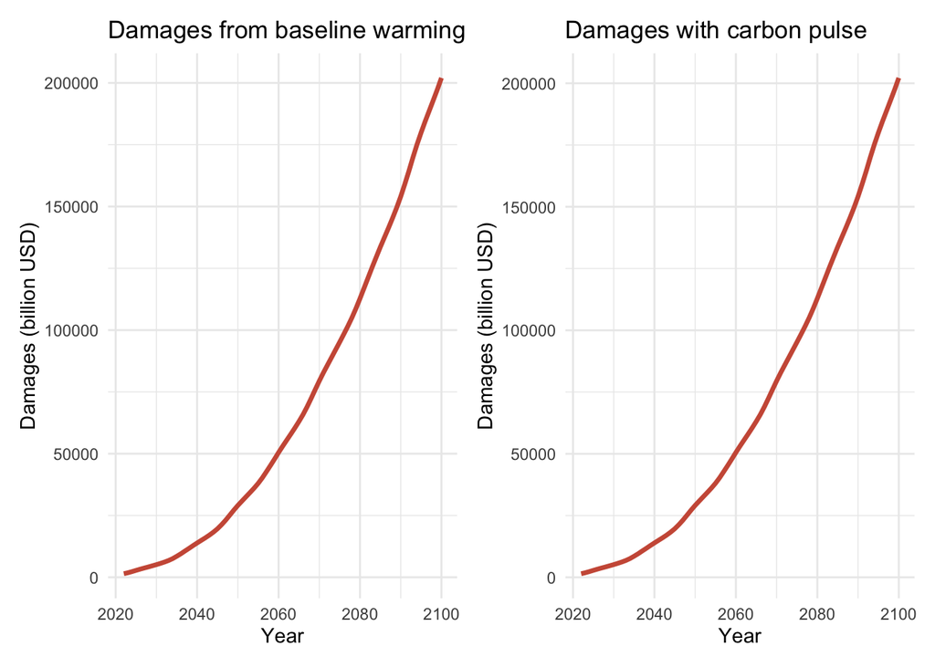

```r
p1 + p2
```

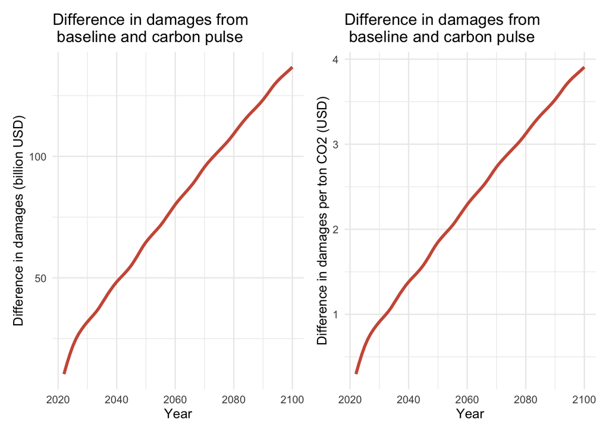

```r
p3 + p4
```

### 3. Social Cost of Carbon

The SCC is the present discounted value of the stream of future damages caused by one additional ton of CO2. The Obama Administration used a discount rate of 3% to discount damages. Recently, New York State used a discount rate of 2%. Calculate and make a plot of the SCC (y-axis) against the discount rate (x-axis) for a reasonable range of discount rates. Explain the intuition for how the discount rate affects the SCC.

```r
# create a new df with discount damages based on various discount rates
scc <- pulse %>%
  mutate(years_into_future = year-2022) %>%
  mutate(scc_not_discounted = difference/35e+9) %>%
  mutate(dr0.25 = scc_not_discounted/(1.0025^years_into_future)) %>%
  mutate(dr0.5 = scc_not_discounted/(1.005^years_into_future)) %>%
  mutate(dr0.75 = scc_not_discounted/(1.0075^years_into_future)) %>%
  mutate(dr1 = scc_not_discounted/(1.01^years_into_future)) %>%
  mutate(dr1.5 = scc_not_discounted/(1.015^years_into_future)) %>%
  mutate(dr2 = scc_not_discounted/(1.02^years_into_future)) %>%
  mutate(dr3 = scc_not_discounted/(1.03^years_into_future)) %>%
  mutate(dr4 = scc_not_discounted/(1.04^years_into_future)) %>%
  mutate(dr5 = scc_not_discounted/(1.05^years_into_future)) %>%
  mutate(dr6 = scc_not_discounted/(1.06^years_into_future)) %>%
  mutate(dr2.1 = scc_not_discounted/(1.021^years_into_future))

scc0.025 <- sum(scc$dr0.25)
scc0.5 <- sum(scc$dr0.5)
scc0.75 <- sum(scc$dr0.75)
scc1 <- sum(scc$dr1)
scc1.5 <- sum(scc$dr1.5)
scc2 <- sum(scc$dr2)
scc3 <- sum(scc$dr3)
scc4 <- sum(scc$dr4)
scc5 <- sum(scc$dr5)
scc6 <- sum(scc$dr6)

scc_vector <- c(scc0.025, scc0.5, scc0.75, scc1, scc1.5, scc2, scc3, scc4, scc5, scc6)
dr <- c(0.25, 0.5, 0.75, 1, 1.5, 2, 3, 4, 5, 6)
scc_table <- data.frame(scc_vector, dr)
```

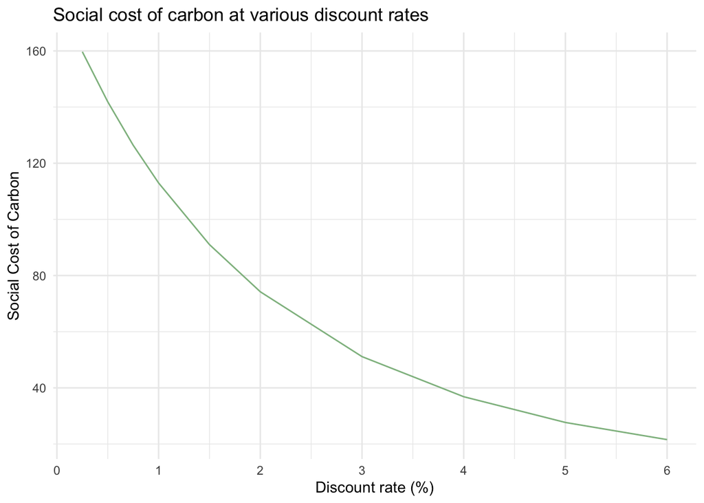

```r
# plotting SCC vs. discount rate
ggplot(data = scc_table, aes(x = dr, y = scc_vector)) +
    geom_line(color = "darkseagreen") +
  labs(x = "Discount rate (%)", y = "Social Cost of Carbon") +
  theme_minimal() +
  scale_x_continuous(n.breaks = 10) +
  labs(title = "Social cost of carbon at various discount rates")
```

### 4. Ramsey Rule

The National Academies of Sciences, Engineering, and Medicine advised the government in a 2017 report to use the Ramsey Rule when discounting within the SCC calculation: r = ρ + ηg. Using ρ = 0.001, η = 2, and g = 0.01, what is the SCC? Locate this point on your graph from above.

```r
# calculate discount rate based on ramsey rule
ramsey <- (0.001 + 2*0.01)*100
```

Under the Ramsey Rule, our discount rate is **2.1%**

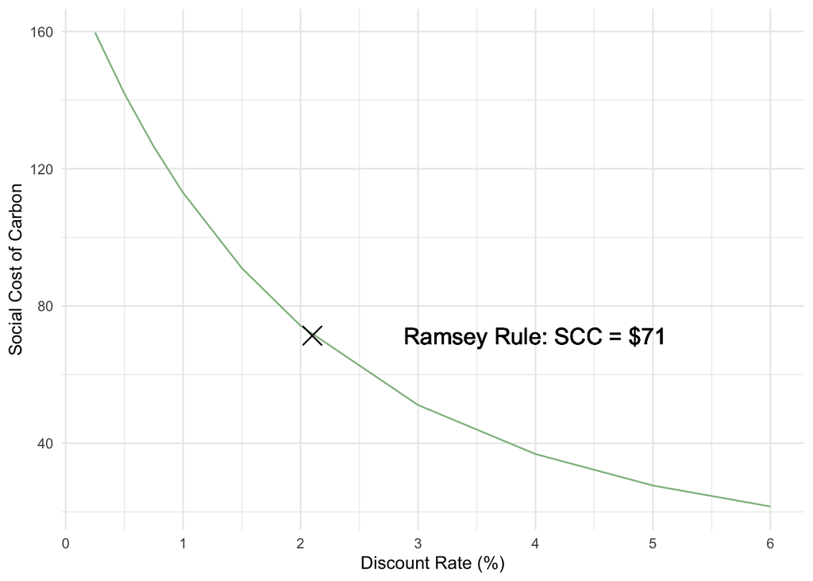

```r
# caclulate scc under ramsey rule
scc2.1 <- sum(scc$dr2.1)


# apply scc to discount graph
ggplot(data = scc_table, aes(x = dr, y = scc_vector)) +
  geom_line(alpha = 2, color = "darkseagreen") +
  labs(x = "Discount Rate (%)", y = "Social Cost of Carbon") +
  theme_minimal() +
  scale_x_continuous(n.breaks = 10) +
  geom_point(aes(y = scc2.1, x = ramsey), size = 5, shape = 4) +
  geom_text(aes(y = scc2.1, x = 4, label = "Ramsey Rule: SCC = $71"), size = 5, shape = 8)
```

### 5. Possible Climate Policies

Now suppose there are two possible climate policies that can be pursued. Policy A is business as usual and Policy B is to take immediate and strong action on climate change. Use these facts: - If you undertake Policy A there are two possible outcomes. Either warming will occur as in the “baseline” (i.e. “no-pulse”) dataset above (this happens with probability 0.5) or warming each year will be 1.5 times that in the “baseline” dataset (with probability 0.5). - Under Policy B, warming will continue until 2050 as in the “baseline” dataset, and then will stabilize at 1.29 degrees and stay that way forever. - Society is risk neutral - Use a discount rate of 2%

What is the expected present value of damages up to 2100 under Policy A? What is the expected present value of damages up to 2100 under Policy B? Suppose undertaking Policy A costs zero and undertaking Policy B costs X. The total cost of a policy is the implementation cost plus expected damages. Make a plot of total cost of Policy A and total cost of Policy B against X. Suppose Congress wants to undertake the policy with the lower total cost. Use your graph to advise Congress.

```r
# data frame of expected values
policy <- pulse %>%
  mutate(warming_policy_a = 1.5*warming_baseline) %>% # 0.5 probabilty under A
  mutate(warming_policy_b = ifelse(year < 2050, warming_policy_a, 1.29)) %>% # 100% probability under B
  mutate(damages_a = damages(warming_policy_a)) %>%
  mutate(damages_b = damages(warming_policy_b)) %>%
  mutate(years_into_future = year-2022) %>%
  mutate(damages_a_discounted = damages_a/(1.02^years_into_future)) %>%
  mutate(damages_b_discounted = damages_b/(1.02^years_into_future)) %>%
  mutate(damages_baseline_discounted = damages_baseline/(1.02^years_into_future))

# expected values
ev_a <- 0.5*sum(policy$damages_baseline_discounted) + 0.5*sum(policy$damages_a_discounted)
ev_b <- sum(policy$damages_b_discounted)
```

**Expected Present Values Under Scenarios A & B**

Present value of damages under Policy A: **$3.02e6 billion**  
Present value of damages under Policy B: **$1.06e6 billion**

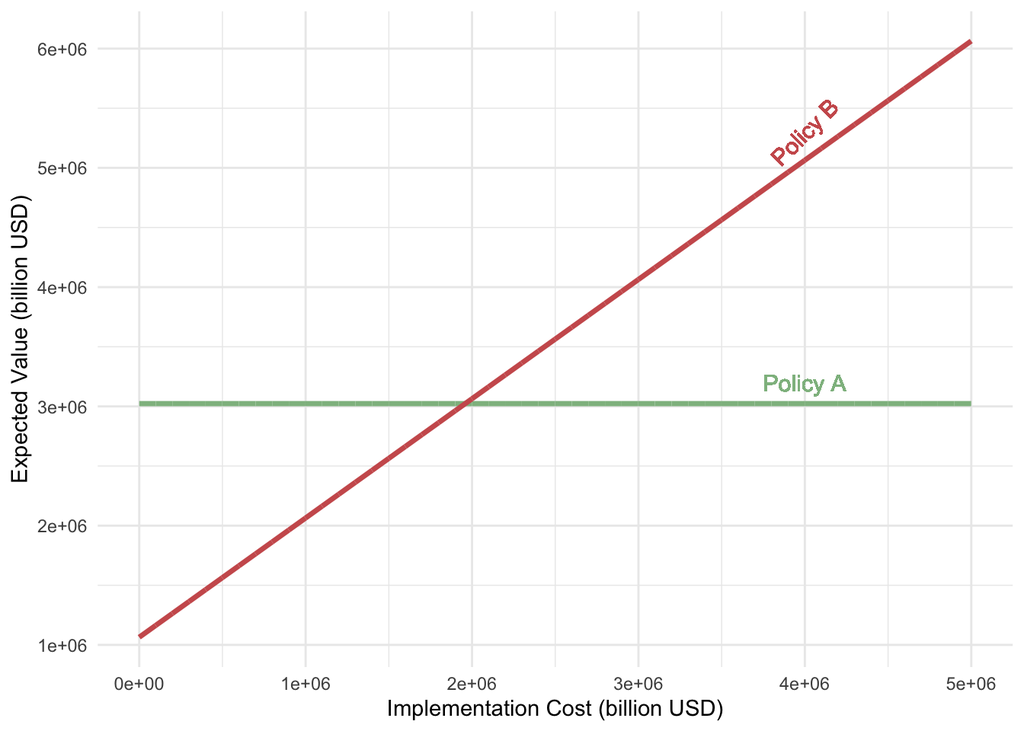

```r
# cost sequence
cost <- seq(0, 5e15, by = 1e12)

cost_df <- data.frame(cost)

cost_compare <- cost_df %>%
  mutate(cost_b = ev_b + cost) %>%
  mutate(cost_a = ev_a)

# visualizing cost and damages of policy options
ggplot(data = cost_compare) +
  geom_line(aes(x = cost/1e9, y = cost_a/1e9), size = 1.2, color = "darkseagreen") +
  geom_line(aes(x = cost/1e9, y = cost_b/1e9), size = 1.2, color = "indianred") +
  theme_minimal() +
  labs(x = "Implementation Cost (billion USD)", y = "Expected Value (billion USD)") +
  geom_text(aes(x = 4e6, y = 3.2e6, label = "Policy A"), color = "darkseagreen", size = 4) +
  geom_text(aes(x = 4e6, y = 5.3e6, label = "Policy B"), color = "indianred", angle = 45, size = 4)
```

**Advice to Congress:**

We would advise Congress that if the cost of implementation is below about $2e+06 billion, Policy A will have the highest expected value. Above that implementation cost, Policy B will have an increasingly higher expected value. Considering most climate policies have a smaller implementation cost than this, we recommend Congress take action on climate policy now.